# Доклад на тему:Идентификация и аутентификация, управление доступом

Основы информационной безопасности

Симонова Полина Игоревна

kulyabov-ds@rudn.ru

Российский университет дружбы народов

2026-05-01

# Информация

## Докладчик

Симонова Полина Игоревна

студентка группы НКАбд-02-24

Российский университет дружбы народов им. П. Лумумбы

1132246738@rudn.ru

https://o5o6am.github.io/ru/

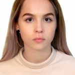

# Вводная часть

## Актуальность

В эпоху цифровизации утечки данных растут: 80% взломов происходят из-за слабой аутентификации.

Рассмотрим ключевые методы идентификации, аутентификации и методы управления доступом в современных системах информационной безопасности.

# Цели и задачи

Изучить механизмы аутентификации и идентификации, методы управления доступом, описать их теоретические основы.

# Материалы и методы

Материалы: Учебники, стандарты (NIST 800-63B ), статьи.

Методы: Системный анализ, сравнение моделей, обзор протоколов (OAuth, FIDO2).

# Содержание исследования

## Аутентификация и идентификация

Идентификация - это процесс, при котором субъект предоставляет системе уникальный идентификатор, чтобы система могла его опознать.

Аутентификация (подтверждение личности) следует за идентификацией и подтверждает подлинность субъекта с помощью факторов вроде пароля, пин-кода или sms-сообщения.

[figure not shown]

Идентификация, аутентификация и авторизация

## Механизмы и методы

Идентификация работает по принципу сопоставления предоставленного идентификатора с базой данных системы: пользователь вводит логин или предъявляет токен, система ищет его в каталоге (LDAP, Active Directory) и возвращает профиль с ролями.

Аутентификацию можно разделить по факторам: «что знаешь» (пароль), «что имеешь» (токен), «кто ты» (биометрия), «где находишься» (геолокация)

[figure not shown]

Методы аутентификации

## Управление доступом

Управление доступом — это процесс, который определяет, какие действия разрешены пользователю после успешной идентификации и аутентификации.

В задачи управления доступом входят назначение прав, контроль их использования, ограничение несанкционированных действий, журналирование и аудит.

## Модели управления доступом

Таблица 1: Сравнение моделей управления доступом

| Модель | Описание | Пример использования | Особенности |
| --- | --- | --- | --- |
| DAC | Владелец сам назначает доступ | Файлы в ОС | Гибкость |
| MAC | Доступ по строгим правилам | Военные системы | Высокая безопасность |
| RBAC | Доступ на основе ролей | Корпоративные системы | Удобство управления |
| ABAC | Доступ по атрибутам (время, место и т.д.) | Современные системы | Гибкость и сложность |

## Современные стандарты

Современные IAM-системы централизуют управление с федеративной аутентификацией (OAuth 2.0, OpenID Connect, SAML) для единого входа (SSO).

Модель Zero Trust (NIST SP 800-207) проверяет каждый запрос по контексту (устройство, поведение)

NIST SP 800-63 определяет уровни IAL (идентификация), AAL (аутентификация, MFA/FIDO2) и FAL (федерация), снижая риски фишинга.

## Проблемы и риски

Основные угрозы в этой области связаны с кражей паролей, подделкой учетных данных, перехватом сеансов, ошибками в настройке прав и чрезмерными привилегиями.

Еще одна проблема — человеческий фактор: пользователи часто выбирают слабые пароли, повторно используют их на разных сервисах или передают другим лицам.

# Заключение

Идентификация, аутентификация и управление доступом — это взаимосвязанные элементы единой системы защиты информации. Идентификация отвечает за распознавание субъекта, аутентификация подтверждает его личность, а управление доступом определяет пределы его полномочий.